# Sime Series Analysis for Oil Price Forecasting

Lawshia Prabath, Shweta Hatote

2023-12-03

# **Pre-Processing**

## **Data Source**

##### This project relies on a publicly available dataset from Kaggle repository, a reputable and widely utilized resource in the scientific community. Daily oil price. Includes values during both the train and test data timeframes. (Ecuador is an oil-dependent country and it’s economical health is highly vulnerable to shocks in oil prices.)

## **Import Data**

```r
dataframe <- read.csv("oil.csv")
dataframe$date <- as.Date(dataframe$date)
```

### Sample input data

```r
head(dataframe)
```

```
##         date dcoilwtico
## 1 2013-01-01         NA
## 2 2013-01-02      93.14
## 3 2013-01-03      92.97
## 4 2013-01-04      93.12
## 5 2013-01-07      93.20
## 6 2013-01-08      93.21
```

## **Exploratory Data Analysis**

### Summary of input data

```r
summary(dataframe)
```

```
##       date              dcoilwtico
##  Min.   :2013-01-01   Min.   : 26.19
##  1st Qu.:2014-03-03   1st Qu.: 46.41
##  Median :2015-05-02   Median : 53.19
##  Mean   :2015-05-02   Mean   : 67.71
##  3rd Qu.:2016-06-30   3rd Qu.: 95.66
##  Max.   :2017-08-31   Max.   :110.62
##                       NA's   :43
```

### Timeseries plot for the data (without imputation)

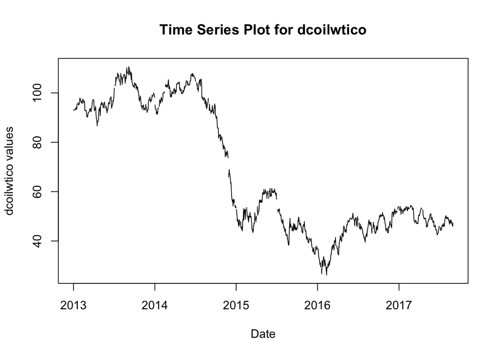

```r
dataframe$date <- as.Date(dataframe$date)

plot(dataframe$date, dataframe$dcoilwtico, type = "l",
     main = "Time Series Plot for dcoilwtico",
     xlab = "Date",
     ylab = "dcoilwtico values")
```

## **Imputation methods**

#### In handling missing data in our time series, we explored three methods:

#### 1. Deleting records

#### 2. KNN imputation with mean values

#### 3. Statistical-based methods.

### **Method 1. Deletion Method**

#### Deleting all the missing value records from the data

```r
method1_df <- na.omit(dataframe)
head(method1_df)
```

```
##         date dcoilwtico
## 2 2013-01-02      93.14
## 3 2013-01-03      92.97
## 4 2013-01-04      93.12
## 5 2013-01-07      93.20
## 6 2013-01-08      93.21
## 7 2013-01-09      93.08
```

### Shape before deleting

```r
dim(dataframe)
```

```
## [1] 1218    2
```

### Shape after deleting missing records

```r
dim(method1_df)
```

```
## [1] 1175    2
```

### **Method 2. Neighbor Based Method**

#### Finding the nearest neighbors of the missing values through other attributes, and then updating the missing values with the mean value of these neighbors

```r
#install.packages("imputeTS")
library(imputeTS)
#install.packages("VIM")
library(VIM)
dataframe$dcoilwtico <- as.numeric(as.character(dataframe$dcoilwtico))
dataframe$date <- as.Date(as.character(dataframe$date))
data_matrix <- data.matrix(dataframe)
```

```r
head(data_matrix)
```

```
##       date dcoilwtico
## [1,] 15706         NA
## [2,] 15707      93.14
## [3,] 15708      92.97
## [4,] 15709      93.12
## [5,] 15712      93.20
## [6,] 15713      93.21
```

```r
data_matrix <- data.matrix(dataframe)
set.seed(123)
train_indices <- sample(1:nrow(data_matrix), 0.8 * nrow(data_matrix))
train_data <- data_matrix[train_indices, ]
test_data <- data_matrix[-train_indices, ]
k_values <- 1:10
```

```r
mse_values <- sapply(k_values, function(k) {
  knn_imputed_data <- kNN(train_data, variable = c("dcoilwtico"), k = k)
  mse <- mean((test_data[, "dcoilwtico"] - knn_imputed_data[-train_indices, "dcoilwtico"])^2, na.rm = TRUE)
  return(mse)
})
```

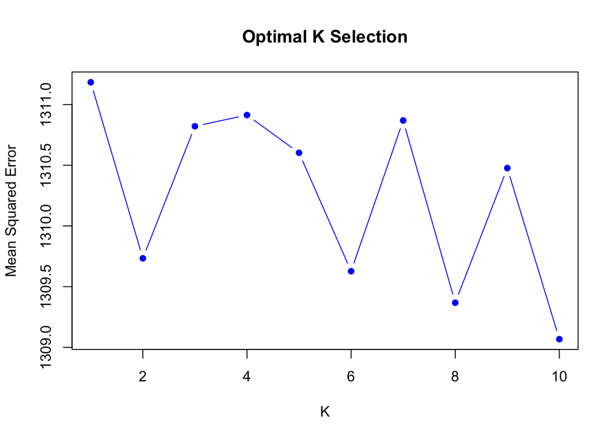

```r
plot(k_values, mse_values, type = "b", pch = 16, col = "blue", xlab = "K", ylab = "Mean Squared Error", main = "Optimal K Selection")
```

#### Since we cannot observe any conrete elbow point here we are going ahead with 8 which has low MSE

```r
KnnImputation1 <- kNN(data_matrix, variable = c("dcoilwtico"), k = 8)
```

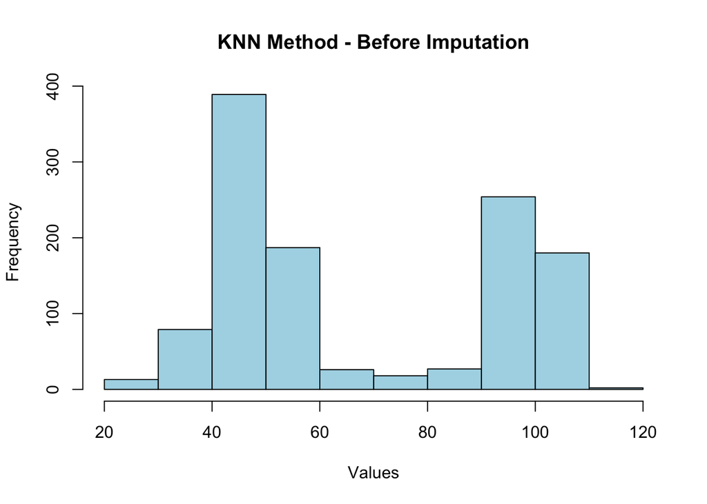

```r
hist(dataframe$dcoilwtico, main = "KNN Method - Before Imputation", xlab = "Values", col = "lightblue", border = "black")
```

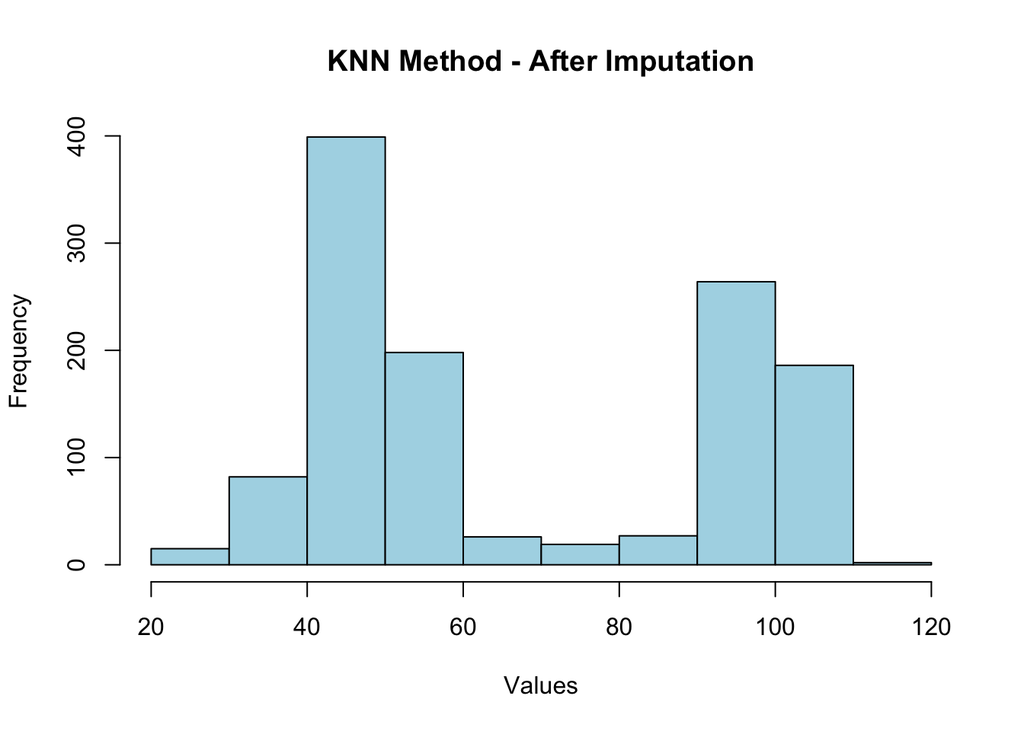

```r
hist(KnnImputation1$dcoilwtico, main = "KNN Method - After Imputation", xlab = "Values", col = "lightblue", border = "black")
```

## **Method 3. Statistical based methods**

#### Simple statistical methods just utilize the data in the original data to impute the missing values, such as take the mean value or median value of the attribute to impute

```r
#install.packages("dplyr")
library(dplyr)
columns_to_impute <- c("dcoilwtico")

method3_df <- dataframe %>%
  mutate_at(columns_to_impute, ~ifelse(is.na(.), mean(., na.rm = TRUE), .))
```

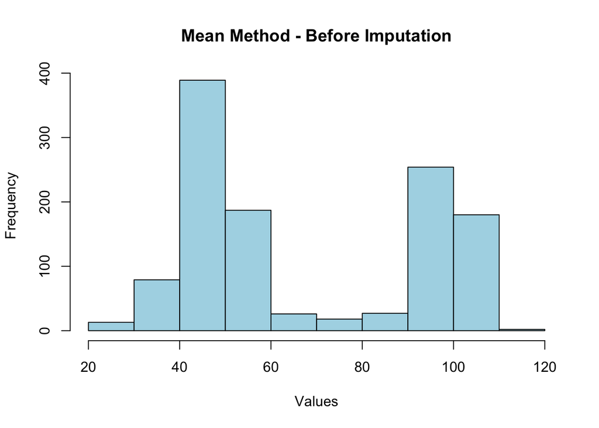

```r
hist(dataframe$dcoilwtico, main = "Mean Method - Before Imputation", xlab = "Values", col = "lightblue", border = "black")
```

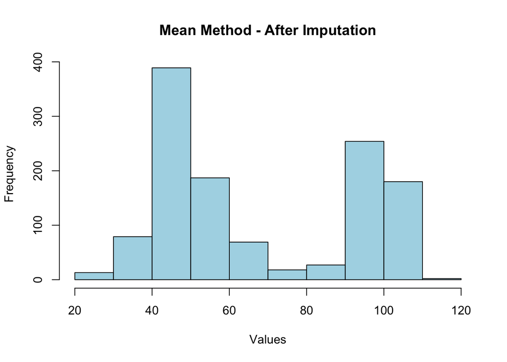

```r
hist(method3_df$dcoilwtico, main = "Mean Method - After Imputation", xlab = "Values", col = "lightblue", border = "black")
```

### **Summary of the data before imputation**

```r
summary(dataframe)
```

```
##       date              dcoilwtico
##  Min.   :2013-01-01   Min.   : 26.19
##  1st Qu.:2014-03-03   1st Qu.: 46.41
##  Median :2015-05-02   Median : 53.19
##  Mean   :2015-05-02   Mean   : 67.71
##  3rd Qu.:2016-06-30   3rd Qu.: 95.66
##  Max.   :2017-08-31   Max.   :110.62
##                       NA's   :43
```

### **Summary of the data after deleting records**

```r
summary(method1_df)
```

```
##       date              dcoilwtico
##  Min.   :2013-01-02   Min.   : 26.19
##  1st Qu.:2014-03-04   1st Qu.: 46.41
##  Median :2015-05-04   Median : 53.19
##  Mean   :2015-05-02   Mean   : 67.71
##  3rd Qu.:2016-06-30   3rd Qu.: 95.66
##  Max.   :2017-08-31   Max.   :110.62
```

### **Summary of the data after KNN imputation**

```r
summary(KnnImputation1)
```

```
##       date         dcoilwtico     dcoilwtico_imp
##  Min.   :15706   Min.   : 26.19   Mode :logical
##  1st Qu.:16132   1st Qu.: 46.42   FALSE:1175
##  Median :16558   Median : 53.19   TRUE :43
##  Mean   :16558   Mean   : 67.68
##  3rd Qu.:16983   3rd Qu.: 95.63
##  Max.   :17409   Max.   :110.62
```

### **Summary of the data after Mean imputation**

```r
summary(method3_df)
```

```
##       date              dcoilwtico
##  Min.   :2013-01-01   Min.   : 26.19
##  1st Qu.:2014-03-03   1st Qu.: 46.70
##  Median :2015-05-02   Median : 53.92
##  Mean   :2015-05-02   Mean   : 67.71
##  3rd Qu.:2016-06-30   3rd Qu.: 95.33
##  Max.   :2017-08-31   Max.   :110.62
```

### **Time series plot comparison**

#### Timeseries plot for the data (without imputation)

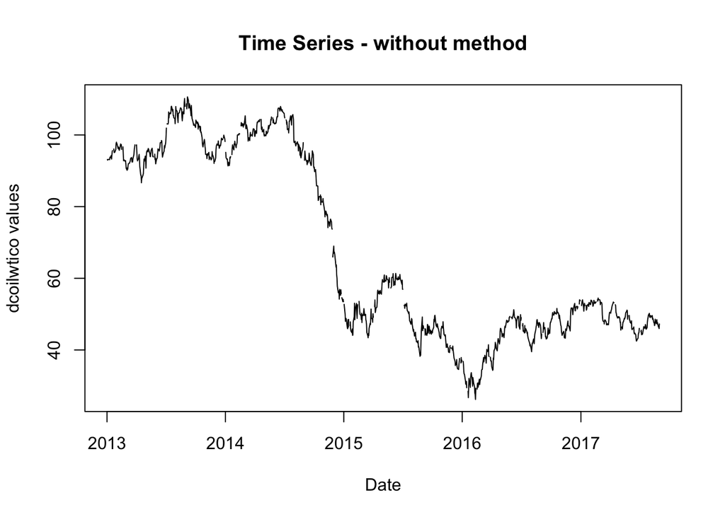

```r
dataframe$date <- as.Date(dataframe$date, format="%d/%m/%y")

plot(dataframe$date, dataframe$dcoilwtico, type = "l",
     main = "Time Series - without method",
     xlab = "Date",
     ylab = "dcoilwtico values")
```

#### Timeseries plot for the data (with deletion method)

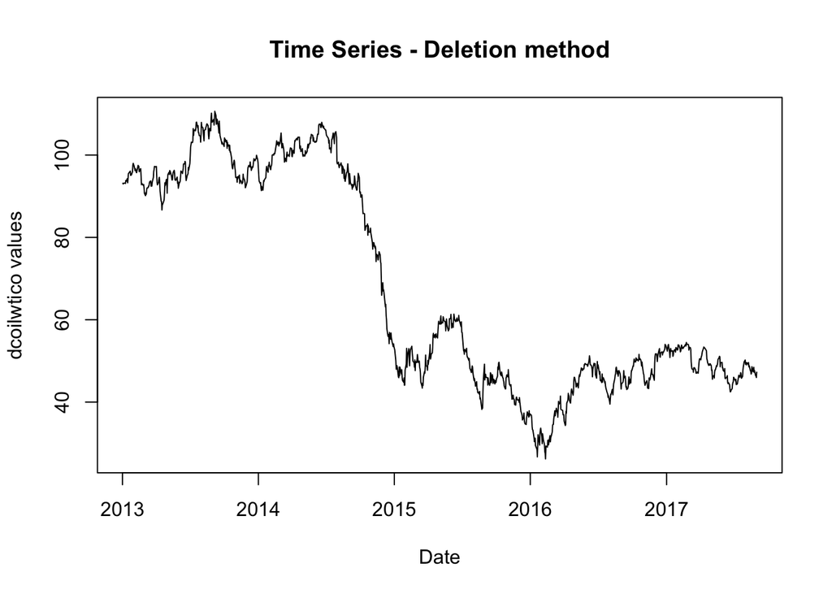

```r
plot(method1_df$date, method1_df$dcoilwtico, type = "l",
     main = "Time Series - Deletion method",
     xlab = "Date",
     ylab = "dcoilwtico values")
```

#### Timeseries plot for the data (with KNN method)

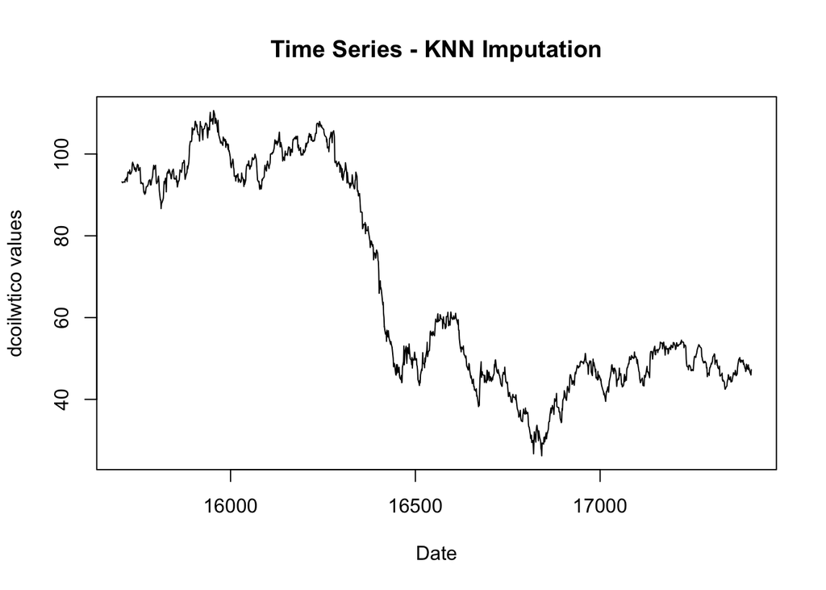

```r
plot(KnnImputation1$date, KnnImputation1$dcoilwtico, type = "l",
     main = "Time Series - KNN Imputation",
     xlab = "Date",
     ylab = "dcoilwtico values")
```

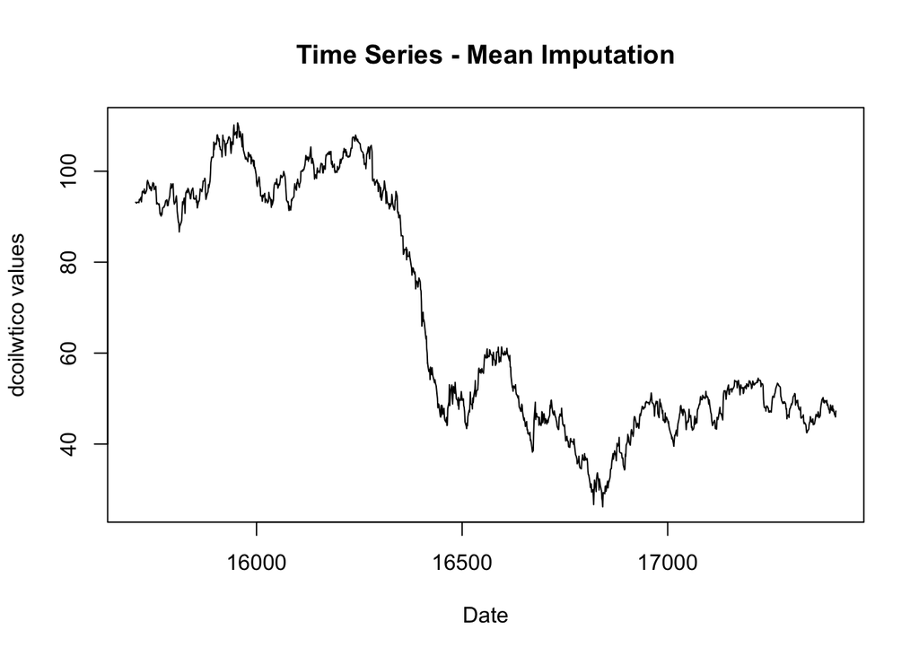

```r
plot(KnnImputation1$date, KnnImputation1$dcoilwtico, type = "l",
     main = "Time Series - Mean Imputation",
     xlab = "Date",
     ylab = "dcoilwtico values")
```

#### After careful consideration, we opted for KNN imputation. This choice was influenced by its ability to retain all data points, unlike the deletion method, and its reliance on neighboring data points rather than the entire dataset, as seen in statistical methods. Recognizing the minimal differences among imputation techniques, we found KNN to strike a balance, offering preservation of data integrity and a localized approach for effective imputation in our time series analysis.

### **Check the seasonality**

### Timeseries plot for the data (with KNN method)

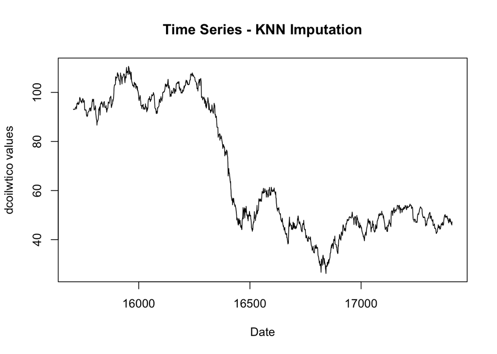

```r
plot(KnnImputation1$date, KnnImputation1$dcoilwtico, type = "l",
     main = "Time Series - KNN Imputation",
     xlab = "Date",
     ylab = "dcoilwtico values")
```

#### There is no evident seasonality in the above graph

```r
KnnImputation1 <- subset(KnnImputation1, select = -dcoilwtico_imp)
head(KnnImputation1)
```

```
##    date dcoilwtico
## 1 15706      93.17
## 2 15707      93.14
## 3 15708      92.97
## 4 15709      93.12
## 5 15712      93.20
## 6 15713      93.21
```

### **Saving the cleaned data into a excel file**

```r
library(openxlsx)


excel_file_path <- "final_data.xlsx"


write.xlsx(KnnImputation1, excel_file_path, rowNames = FALSE)
```

# **Modelling**

### **ETS**

##### ETS models, also known as Exponential Trend Smoothing models, are a family of statistical forecasting models that are used to forecast time series data characterized by trend and seasonality. They are based on the concept of exponential smoothing, which is a technique for estimating the value of a variable at a future time based on its past values.

### **Components of ETS Models**

##### ETS models are characterized by three main components:

##### 1. Level: The level component represents the current level of the time series. It is estimated using exponential smoothing, which gives more weight to recent observations than the older observations.

##### 2. Trend: The trend component represents the underlying trend of the time series. It is estimated using a damped exponential smoothing filter, which allows the trend to change over time.

##### 3. Seasonality: The seasonality component represents the seasonal pattern of the time series. It is estimated using a multiplicative seasonal factor, which is applied to the level and trend components.

### **Types of ETS Models**

##### 1. ETS(A,N,N)

##### 2. ETS(M,N,N)

##### 3. ETS(A,A,N)

```r
#install.packages("forecast")
#install.packages("readxl")
library(forecast)
library(readxl)
```

```r
final_data <- read_excel("final_data.xlsx")

# Convert the "date" column to Date format
final_data$date <- as.Date(final_data$date, origin="1970-01-01")

# Extract the univariate time series
ts_data <- ts(final_data$dcoilwtico, frequency = 1)  # Adjust the frequency based on your data
```

## **Model 1. ETS(A,N,N)**

```r
# Set the length of the training set
total_length <- length(ts_data)
train_length <- total_length - 30

# Split the data into training and testing sets
train_data <- ts_data[1:train_length]
test_data <- ts_data[(train_length + 1):total_length]

# Fit the ETS model on the training data
ets_ann <- ets(train_data, model = "ANN")

# Ljung-Box test on residuals
ljung_box_test <- Box.test(residuals(ets_ann), lag = 12, type = "Ljung-Box")

# Print the results of the Ljung-Box test
cat("Ljung-Box Test:\n")
```

```
## Ljung-Box Test:
```

```r
print(ljung_box_test)
```

```
##
##  Box-Ljung test
##
## data:  residuals(ets_ann)
## X-squared = 6.9266, df = 12, p-value = 0.8624
```

```r
# Print the results
print(ets_ann)
```

```
## ETS(A,N,N)
##
## Call:
##  ets(y = train_data, model = "ANN")
##
##   Smoothing parameters:
##     alpha = 0.9485
##
##   Initial states:
##     l = 93.1779
##
##   sigma:  1.1947
##
##      AIC     AICc      BIC
## 8837.671 8837.691 8852.911
```

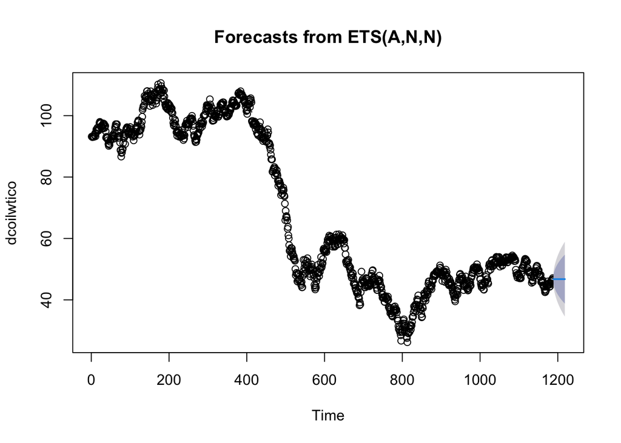

```r
# Plot the forecasts on the training set
plot(forecast(ets_ann, h = 30), type = 'b', xlab = 'Time', ylab = 'dcoilwtico')
abline(h = coef(ets_ann)[names(coef(ets_ann)) == 'intercept'])
```

```r
# Extract the actual values from the test set
actual_values <- test_data

# Extract the forecasted values from the ETS model
forecast_values <- forecast(ets_ann, h = 30)$mean

# Calculate RMSE on the test set
rmse_ets_ann <- sqrt(mean((actual_values - forecast_values)^2))

# Print RMSE
cat("RMSE_ETS_ANN:", rmse_ets_ann, "\n")
```

```
## RMSE_ETS_ANN: 1.807734
```

##### From the Ljung-Box test we get p-value as 0.8624 indicating that there is no significant autocorrelation in the residuals up to the 12th lag. This is a positive result, suggesting that the residuals exhibit no detectable temporal patterns. Hence, the Ljung-Box test suggests that the model residuals do not exhibit significant autocorrelation, supporting the adequacy of the model.

## **Model 2. ETS(M,N,N)**

```r
# Set the length of the training set
total_length <- length(ts_data)
train_length <- total_length - 30

# Split the data into training and testing sets
train_data <- ts_data[1:train_length]
test_data <- ts_data[(train_length + 1):total_length]

# Fit the ETS model on the training data
ets_mnn <- ets(train_data, model = "MNN")

# Ljung-Box test on residuals
ljung_box_test <- Box.test(residuals(ets_mnn), lag = 12, type = "Ljung-Box")

# Print the results of the Ljung-Box test
cat("Ljung-Box Test:\n")
```

```
## Ljung-Box Test:
```

```r
print(ljung_box_test)
```

```
##
##  Box-Ljung test
##
## data:  residuals(ets_mnn)
## X-squared = 6.8526, df = 12, p-value = 0.8672
```

```r
# Print the results
print(ets_mnn)
```

```
## ETS(M,N,N)
##
## Call:
##  ets(y = train_data, model = "MNN")
##
##   Smoothing parameters:
##     alpha = 0.9433
##
##   Initial states:
##     l = 93.1206
##
##   sigma:  0.0223
##
##     AIC    AICc     BIC
## 9234.27 9234.29 9249.51
```

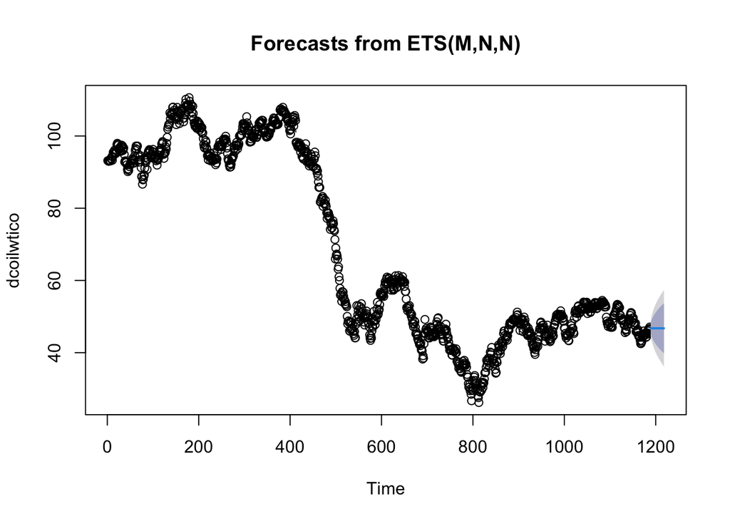

```r
# Plot the forecasts on the training set
plot(forecast(ets_mnn, h = 30), type = 'b', xlab = 'Time', ylab = 'dcoilwtico')
abline(h = coef(ets_mnn)[names(coef(ets_mnn)) == 'intercept'])
```

```r
# Extract the actual values from the test set
actual_values <- test_data

# Extract the forecasted values from the ETS model
forecast_values <- forecast(ets_mnn, h = 30)$mean

# Calculate RMSE on the test set
rmse_ets_mnn <- sqrt(mean((actual_values - forecast_values)^2))

# Print RMSE
cat("RMSE_ETS_MNN:", rmse_ets_mnn, "\n")
```

```
## RMSE_ETS_MNN: 1.806623
```

##### From the Ljung-Box test we get p-value as 0.8672, suggesting that there is no significant autocorrelation in the residuals up to the 12th lag. This is a positive result, indicating that the residuals do not exhibit detectable temporal patterns. Hence, the Ljung-Box test suggests that the model residuals do not exhibit significant autocorrelation, supporting the adequacy of the model.

```r
# Set the length of the training set
total_length <- length(ts_data)
train_length <- total_length - 30

# Split the data into training and testing sets
train_data <- ts_data[1:train_length]
test_data <- ts_data[(train_length + 1):total_length]

# Fit the ETS model on the training data
ets_aan <- ets(train_data, model = "AAN")

# Ljung-Box test on residuals
ljung_box_test <- Box.test(residuals(ets_aan), lag = 12, type = "Ljung-Box")

# Print the results of the Ljung-Box test
cat("Ljung-Box Test:\n")
```

```
## Ljung-Box Test:
```

```r
print(ljung_box_test)
```

```
##
##  Box-Ljung test
##
## data:  residuals(ets_aan)
## X-squared = 5.5705, df = 12, p-value = 0.9362
```

```r
# Print the results
print(ets_aan)
```

```
## ETS(A,Ad,N)
##
## Call:
##  ets(y = train_data, model = "AAN")
##
##   Smoothing parameters:
##     alpha = 0.9316
##     beta  = 0.0121
##     phi   = 0.9742
##
##   Initial states:
##     l = 93.0633
##     b = 0.0919
##
##   sigma:  1.1944
##
##      AIC     AICc      BIC
## 8840.228 8840.299 8870.708
```

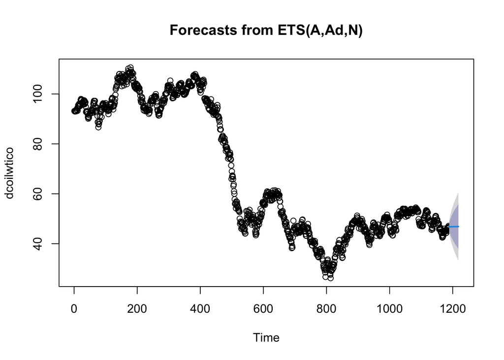

```r
# Plot the forecasts on the training set
plot(forecast(ets_aan, h = 30), type = 'b', xlab = 'Time', ylab = 'dcoilwtico')
abline(h = coef(ets_aan)[names(coef(ets_aan)) == 'intercept'])
```

```r
# Extract the actual values from the test set
actual_values <- test_data

# Extract the forecasted values from the ETS model
forecast_values <- forecast(ets_aan, h = 30)$mean

# Calculate RMSE on the test set
rmse_ets_aan <- sqrt(mean((actual_values - forecast_values)^2))

# Print RMSE
cat("RMSE_ETS_AAN:", rmse_ets_aan, "\n")
```

```
## RMSE_ETS_AAN: 1.766991
```

##### From the Ljung-Box test we get p-value as 0.9362, indicating that there is no significant autocorrelation in the residuals up to the 12th lag. This is a positive result, suggesting that the residuals do not exhibit detectable temporal patterns. Hence, the Ljung-Box test suggests that the model residuals do not exhibit significant autocorrelation, supporting the adequacy of the model.

## **Model 4. ARIMA**

#### **Determining the orders for an ARIMA model**

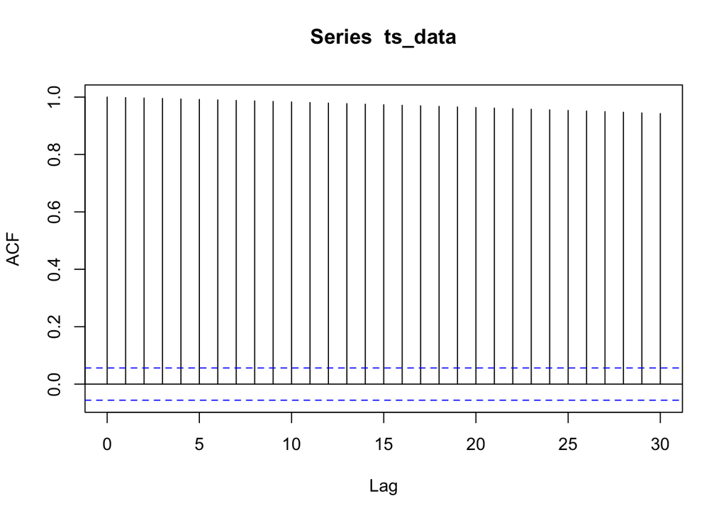

```r
# Determine differencing order (d) for stationarity
d <- ndiffs(ts_data)
# Plot ACF and PACF
acf(ts_data)
```

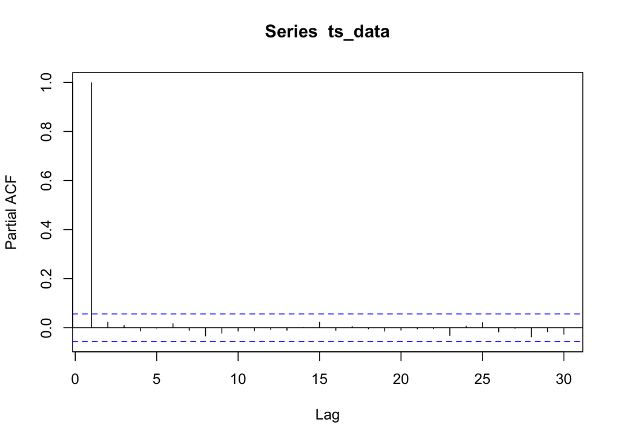

```r
pacf(ts_data)
```

```r
# Grid search for p and q
best_model <- list(order = c(0, d, 0), AIC = Inf)
for (p in 0:3) {
  for (q in 0:3) {
    current_model <- arima(ts_data, order = c(p, d, q))
    current_aic <- AIC(current_model)
    if (current_aic < best_model$AIC) {
      best_model$order <- c(p, d, q)
      best_model$AIC <- current_aic
    }
  }
}
# Fit the best model
final_model <- arima(ts_data, order = best_model$order)
print(final_model)
```

```
##
## Call:
## arima(x = ts_data, order = best_model$order)
##
## Coefficients:
##           ar1      ar2      ma1     ma2      ma3
##       -0.0182  -0.9821  -0.0357  0.9949  -0.0413
## s.e.   0.0116   0.0091   0.0312  0.0092   0.0299
##
## sigma^2 estimated as 1.394:  log likelihood = -1929.67,  aic = 3871.34
```

```r
# Set the length of the training set
total_length <- length(ts_data)
train_length <- total_length - 30

# Split the data into training and testing sets
train_data <- ts_data[1:train_length]
test_data <- ts_data[(train_length + 1):total_length]

# Fit the ARIMA(1,1,2) model on the training data
arima_112 <- arima(train_data, order = c(1, 1, 2))

# Ljung-Box test on residuals
ljung_box_test <- Box.test(residuals(arima_112), lag = 12, type = "Ljung-Box")

# Print the results of the Ljung-Box test
print("Ljung-Box Test:")
```

```
## [1] "Ljung-Box Test:"
```

```r
print(ljung_box_test)
```

```
##
##  Box-Ljung test
##
## data:  residuals(arima_112)
## X-squared = 6.862, df = 12, p-value = 0.8666
```

```r
# Print the results
print(arima_112)
```

```
##
## Call:
## arima(x = train_data, order = c(1, 1, 2))
##
## Coefficients:
##           ar1     ma1      ma2
##       -0.2538  0.2025  -0.0207
## s.e.   1.0069  1.0065   0.0588
##
## sigma^2 estimated as 1.426:  log likelihood = -1894.87,  aic = 3797.73
```

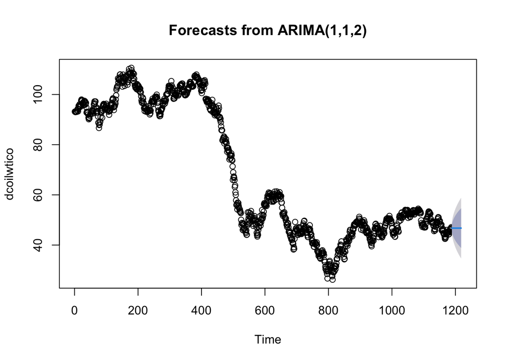

```r
# Plot the forecasts on the training set
plot(forecast(arima_112, h = 30), type = 'b', xlab = 'Time', ylab = 'dcoilwtico')
abline(h = coef(arima_112)[names(coef(arima_112)) == 'intercept'])
```

```r
# Extract the actual values from the test set
actual_values <- test_data

# Extract the forecasted values from the ARIMA model
forecast_values <- forecast(arima_112, h = 30)$mean

# Calculate RMSE on the test set
rmse_arima_112 <- sqrt(mean((actual_values - forecast_values)^2))

# Print RMSE
cat("RMSE_ARIMA_112:", rmse_arima_112, "\n")
```

```
## RMSE_ARIMA_112: 1.809029
```

##### From the Ljung-Box test we get p-value as 0.8666, indicating that there is no significant autocorrelation in the residuals up to the 12th lag. This is a positive result, suggesting that the residuals do not exhibit detectable temporal patterns. Hence, the Ljung-Box test suggests that the model residuals do not exhibit significant autocorrelation, supporting the adequacy of the model.

## **Comparing the RMSE values for all the four models**

```r
cat("RMSE_ETS_ANN:", rmse_ets_ann, "\n")
```

```
## RMSE_ETS_ANN: 1.807734
```

```r
cat("RMSE_ETS_MNN:", rmse_ets_mnn, "\n")
```

```
## RMSE_ETS_MNN: 1.806623
```

```r
cat("RMSE_ETS_AAN:", rmse_ets_aan, "\n")
```

```
## RMSE_ETS_AAN: 1.766991
```

```r
cat("RMSE_ARIMA_112:", rmse_arima_112, "\n")
```

```
## RMSE_ARIMA_112: 1.809029
```

## **RMSE Values**

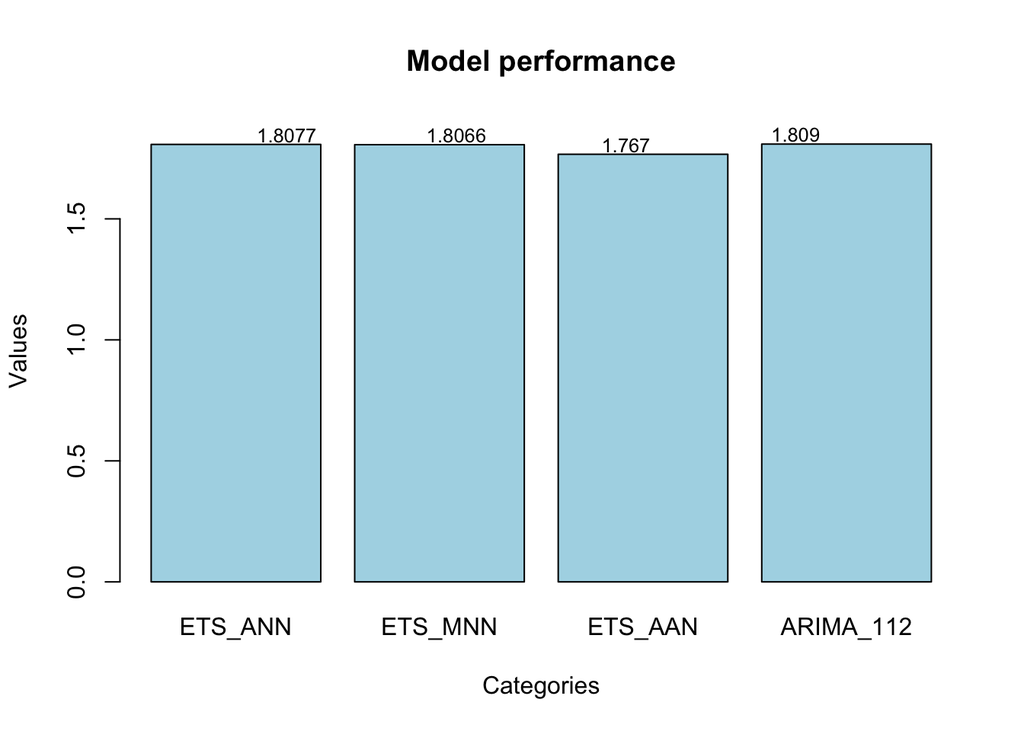

```r
# Example data
values <- c(1.807734, 1.806623, 1.766991, 1.809029)
categories <- c("ETS_ANN", "ETS_MNN", "ETS_AAN", "ARIMA_112")

# Create a bar plot with light blue color and adjusted y-axis
barplot(values, col = "lightblue",
        names.arg = categories,
        main = "Model performance",
        xlab = "Categories",
        ylab = "Values",
        ylim = c(0, max(values) + 0.1))  # Adjust the y-axis limits

# Add labels with precise positioning
# Add labels with dynamic positioning and rotation
text(1:4, ifelse(values > max(values) - 0.1, values - 0.05, values + 0.05),
     labels = round(values, 4), col = "black", pos = 3, cex = 0.8)  # Adjust label position and size
```

##### ETS_AAN outperforms the other models in terms of minimizing the average magnitude of errors between actual and forecasted values.

##### While the differences in RMSE values are relatively small, choosing the model with the lowest RMSE is generally a good practice for forecasting, as it indicates better predictive accuracy.

##### **Conclusion:**

##### Based on the RMSE values, the ETS_AAN model appears to be the most promising model for forecasting the given time series data among the models we have evaluated.